# Concurrent Programming - List 2

José Benardi de Souza Nunes, Gustavo Diniz Monteiro, Ruan Roberto Eloy Silveira

```r
library(here)
library(boot)
library(readr)
library(dplyr)
library(ggplot2)
library(reshape2)
library(lubridate)

theme_set(theme_bw())
```

# Question 1

## Returns first result

- Code can be found at `code/list2/go-code/ex1/first_return.go`

```c
package main

import (
    "fmt"
    "math/rand"
    "os"
    "strconv"
    "time"
)

func request(id int, fstReturn chan int) {
    sleepTime := 1 + rand.Intn(30)
    fmt.Printf("goroutine %d: sleep %ds\n", id, sleepTime)
    t := time.Duration(sleepTime) * time.Second
    time.Sleep(t)

    fstReturn <- sleepTime
}

func gateway(numReplicas int) int {
    fstReturn := make(chan int)
    for i := 1; i <= numReplicas; i++ {
        go request(i, fstReturn)
    }

    select {
    case value := <-fstReturn:
        return value
    }
}

func main() {
    // set the seed for rand
    rand.Seed(time.Now().UTC().UnixNano())
    numReplicas := 3
    if len(os.Args) > 1 {
        // convert command line arg to int
        numReplicas, _ = strconv.Atoi(os.Args[1])
    }
    fistTime := gateway(numReplicas)
    fmt.Printf("First returned: %d\n", fistTime)
}
```

## Returns combined result

- Code can be found at `code/list2/go-code/ex1/combined_return.go`

```c
package main

import (
    "fmt"
    "math/rand"
    "os"
    "strconv"
    "time"
)

func request(id int, results chan int) {
    sleepTime := 1 + rand.Intn(30)
    fmt.Printf("goroutine %d: sleep %ds\n", id, sleepTime)
    t := time.Duration(sleepTime) * time.Second
    time.Sleep(t)

    results <- sleepTime
}

func gateway(numReplicas int) int {
    results := make(chan int, numReplicas)

    for i := 1; i <= numReplicas; i++ {
        go request(i, results)
    }

    combinedResults := 0
    for i := 1; i <= numReplicas; i++ {
        select {
        case currentResult := <-results:
            combinedResults += currentResult
        }
    }

    return combinedResults
}

func main() {
    // set the seed for rand
    rand.Seed(time.Now().UTC().UnixNano())
    numReplicas := 3
    if len(os.Args) > 1 {
        // convert command line arg to int
        numReplicas, _ = strconv.Atoi(os.Args[1])
    }
    combinedTime := gateway(numReplicas)
    fmt.Printf("Combined return: %d\n", combinedTime)
}
```

# Question 2

## Returns first result

- Code can be found at `code/list2/go-code/ex2/return_first-2a.go`

```c
package main

import (
    "fmt"
    "math/rand"
    "os"
    "strconv"
    "sync"
    "time"
)

type firstReturn struct {
    sync.Mutex
    cond  *sync.Cond
    value int
}

func newFirstReturn() *firstReturn {
    fstReturn := firstReturn{value: -1}
    fstReturn.cond = sync.NewCond(&fstReturn)
    return &fstReturn
}

func request(id int, fstReturn *firstReturn) {
    sleepTime := 1 + rand.Intn(30)
    fmt.Printf("goroutine %d: sleep %ds\n", id, sleepTime)
    t := time.Duration(sleepTime) * time.Second
    time.Sleep(t)

    fstReturn.Lock()
    fstReturn.value = sleepTime
    fstReturn.cond.Signal()
    fstReturn.Unlock()
}

func gateway(numReplicas int) int {
    fstReturn := newFirstReturn()
    go func() {
        timeout := 8
        sleepTime := time.Duration(timeout) * time.Second
        time.Sleep(sleepTime)

        fstReturn.Lock()
        fstReturn.cond.Signal()
        fstReturn.Unlock()
    }()

    for i := 1; i <= numReplicas; i++ {
        go request(i, fstReturn)
    }

    fstReturn.Lock()
    fstReturn.cond.Wait()
    fstReturn.Unlock()

    return fstReturn.value
}

func main() {
    // set the seed for rand
    rand.Seed(time.Now().UTC().UnixNano())
    // convert command line arg to int
    numReplicas := 2
    if len(os.Args) > 1 {
        numReplicas, _ = strconv.Atoi(os.Args[1])
    }
    firstTime := gateway(numReplicas)
    if firstTime > 0 {
        fmt.Printf("First returned: %d\n", firstTime)
    } else {
        fmt.Printf("Gateway returned -1\n")
    }
}
```

## Returns combined result

- Code can be found at `code/list2/go-code/ex2/return_first-2b.go`

```c
package main

import (
    "fmt"
    "math/rand"
    "os"
    "strconv"
    "sync"
    "time"
)

type firstReturn struct {
    sync.Mutex
    value int
}

func request(id int, fstReturn *firstReturn, wg *sync.WaitGroup) {
    sleepTime := 1 + rand.Intn(30)
    fmt.Printf("goroutine %d: sleep %ds\n", id, sleepTime)
    t := time.Duration(sleepTime) * time.Second
    time.Sleep(t)

    fstReturn.Lock()
    fstReturn.value += sleepTime
    fstReturn.Unlock()
    wg.Done()
}

func gateway(numReplicas int) int {
    fstReturn := &firstReturn{value: 0}

    var wg sync.WaitGroup
    wg.Add(numReplicas)

    for i := 1; i <= numReplicas; i++ {
        go request(i, fstReturn, &wg)
    }

    timeout := 16
    sleepTime := time.Duration(timeout) * time.Second
    c := make(chan struct{})

    go func() {
        defer close(c)
        wg.Wait()
    }()

    select {
    case <-c:
        return fstReturn.value
    case <-time.After(sleepTime):
        return -1
    }
}

func main() {
    // set the seed for rand
    rand.Seed(time.Now().UTC().UnixNano())
    // convert command line arg to int
    numReplicas := 2
    if len(os.Args) > 1 {
        numReplicas, _ = strconv.Atoi(os.Args[1])
    }
    combinedTime := gateway(numReplicas)
    if combinedTime > 0 {
        fmt.Printf("Combined return: %d\n", combinedTime)
    } else {
        fmt.Printf("Gateway returned -1\n")
    }
}
```

# Question 3

## Implementation

### Java-Thread implementation

- Code can be found at `code/list2/java-code/ex3/CreateNThreads.java`

```c
public class CreateNThreads {

    public static void main(String[] args) {
        int nthreads = Integer.parseInt(args[0]);

        Thread[] threads = new Thread[nthreads];
        for (int i = 0; i < threads.length; i++) {
            threads[i] = new Thread(new Runnable() {
                public void run() {
                    try {
                        Thread.sleep(3000);
                    } catch (InterruptedException e) {
                        e.printStackTrace();
                    }
                }
            });
            threads[i].start();
        }

        // wait for the threads running in the background to finish
        for (Thread thread : threads) {
            try {
                thread.join();
            } catch (InterruptedException e) {
                e.printStackTrace();
            }
        }
    }
}
```

### Goroutine implementation

- Code can be found at `code/list2/go-code/ex3/goroutines.go`

```c
package main
import (
  "os"
  "time"
  "sync"
  "strconv"
)

var wg sync.WaitGroup

func sub_routine() {
  defer wg.Done()
  time.Sleep(3 * time.Second)
}

func main() {
  args := os.Args[1:]
  // Command line argument (Number of goroutines)
  nroutines, err := strconv.Atoi(args[0])

  if err == nil {
  for i := 0; i < nroutines; i++ {
    wg.Add(1)
    go sub_routine()
  }

  wg.Wait()

  }

}
```

## Employed profiling tool

> [Massif](http://valgrind.org/docs/manual/) is a heap profiler. It measures how much heap memory your program uses. This includes both the useful space, and the extra bytes allocated for book-keeping and alignment purposes. It can also measure the size of a program’s stack(s).

## Data

### Load Data

```r
read_csv(here::here("output/list2/ex3/q3-l2-results.csv"),
         col_types = cols(
           impl = col_character(),
           nflows = col_integer(),
           snapshot = col_integer(),
           time = col_integer(),
           mem_heap_B = col_integer(),
           mem_heap_extra_B = col_integer(),
           mem_stacks_B = col_integer())) %>%
  mutate(impl = as.factor(impl),
         nflows = as.factor(nflows)) %>%
  mutate(impl = recode(impl, golang="Goroutine",
                       java="Java-Thread")) -> data

data %>%
  glimpse()
```

```
## Observations: 694
## Variables: 8
## $ impl             <fct> Goroutine, Goroutine, Goroutine, Goroutine, G...
## $ nflows           <fct> 25, 25, 25, 25, 25, 25, 25, 25, 25, 25, 25, 2...
## $ snapshot         <int> 0, 1, 2, 3, 4, 5, 6, 7, 8, 9, 10, 11, 12, 13,...
## $ time             <int> 0, 15273712, 24301528, 36877512, 54325928, 71...
## $ total_mem        <dbl> 0, 86800, 88200, 94952, 95544, 102440, 102184...
## $ mem_heap_B       <int> 0, 2880, 2880, 4215, 4215, 4215, 4215, 4215, ...
## $ mem_heap_extra_B <int> 0, 80, 80, 433, 433, 433, 433, 433, 433, 433,...
## $ mem_stacks_B     <int> 0, 83840, 85240, 90304, 90896, 97792, 97536, ...
```

### Data Description

- `impl`: Whether it refers to *golang goroutines* or *java threads*
- `nflows`: Number of triggered *golang goroutines* or *java threads*, sequential flow of control, or simply flow of control, will be term used to describe both in this report.
- `time`: The time it was taken. In this case, the time unit is bytes allocated/deallocated** on the heap and stack(s).
- `total_mem`: The total memory consumption at that point.
- `mem_heap_B`: The number of useful heap bytes allocated at that point. This reflects the number of bytes asked for by the program.
- `mem_heap_extra_B`: The number of extra heap bytes allocated at that point. This reflects the number of bytes allocated in excess of what the program asked for. There are two sources of extra heap bytes.
- `mem_stacks_B`: The size of the memory stack(s).

#### Heap vs Stack

##### So what’s the difference between `memory heap` and `memory stack`?

> **Stack** is used for static memory allocation and **Heap** for dynamic memory allocation, both stored in the computer’s RAM

## Analysis by metric

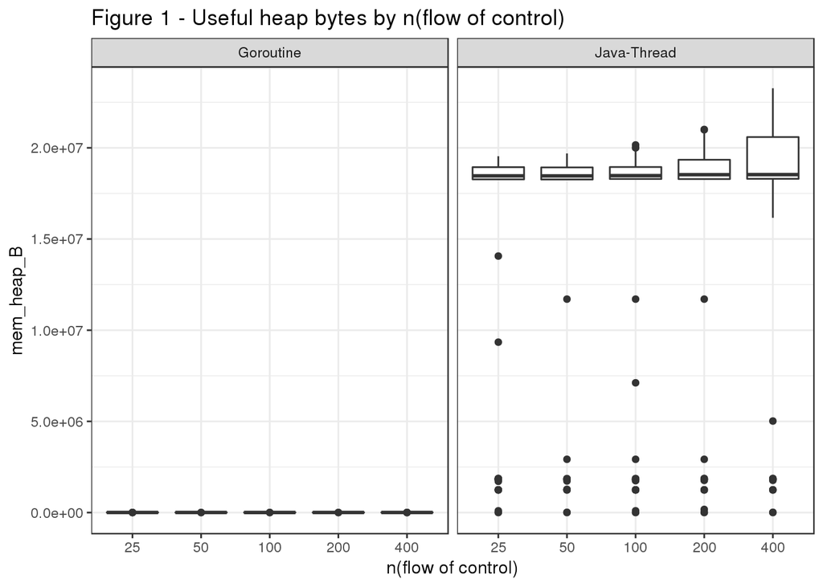

```r
data %>%
  ggplot(aes(nflows,mem_heap_B)) +
  geom_boxplot() +
  facet_wrap(~ impl) +
  labs(x="n(flow of control)",
       title="Figure 1 - Useful heap bytes by n(flow of control)")
```

- There’s substantial indication that overall *java-threads* consume many more *useful heap bytes*, in other words they demand the dynamic allocation of more memory bytes.

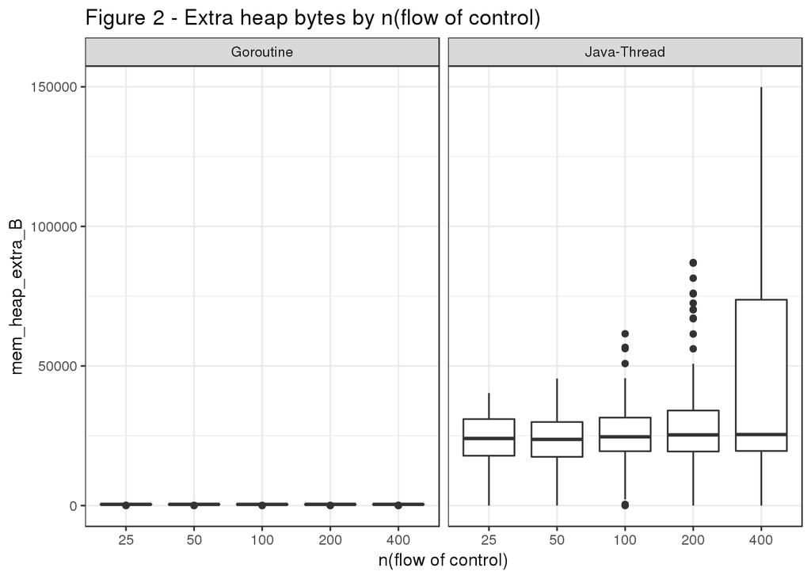

```r
data %>%
  ggplot(aes(nflows,mem_heap_extra_B)) +
  geom_boxplot() +
  facet_wrap(~ impl) +
  labs(x="n(flow of control)",
       title="Figure 2 - Extra heap bytes by n(flow of control)")
```

- In the chart we see clear evidence that overall *java-threads* consume many more *extra heap bytes*.
  - According to [massif docs](http://valgrind.org/docs/manual/ms-manual.html#ms-manual.anexample) usually the memory allocator demands *extra heap bytes* for administrative reasons, and to ensure block alignment.

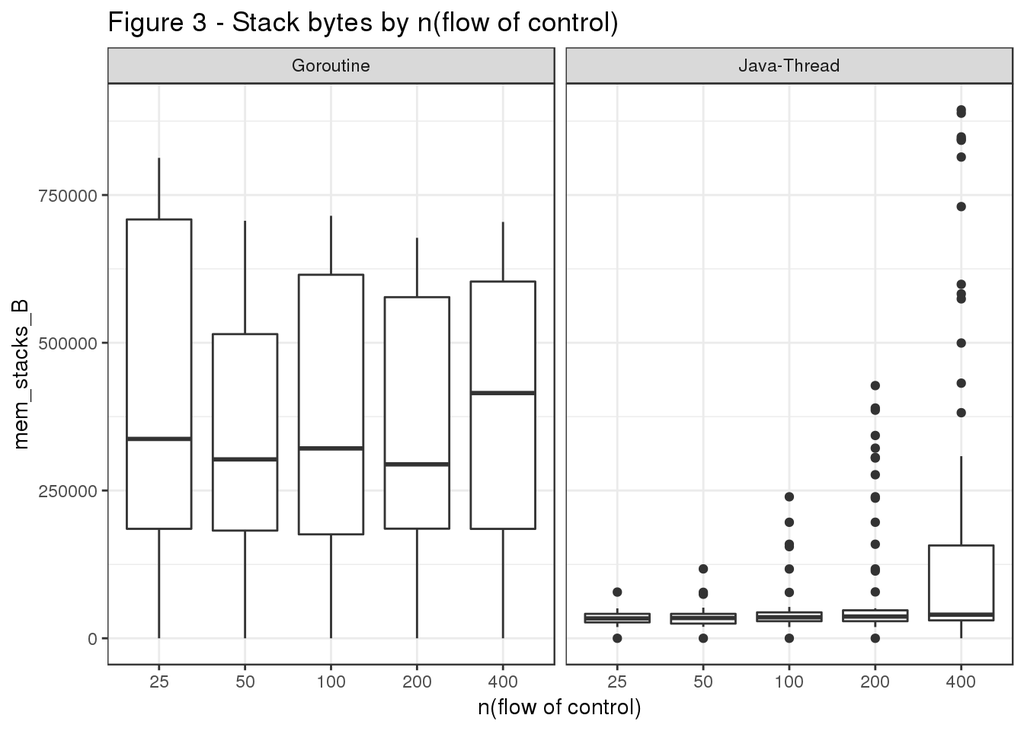

```r
data %>%
  ggplot(aes(nflows,mem_stacks_B)) +
  geom_boxplot() +
  facet_wrap(~ impl) +
  labs(x="n(flow of control)",
       title="Figure 3 - Stack bytes by n(flow of control)")
```

- In the chart we see clear evidence that overall *Goroutines* consume many more *stack bytes*, in other words they demand more static memory allocation.

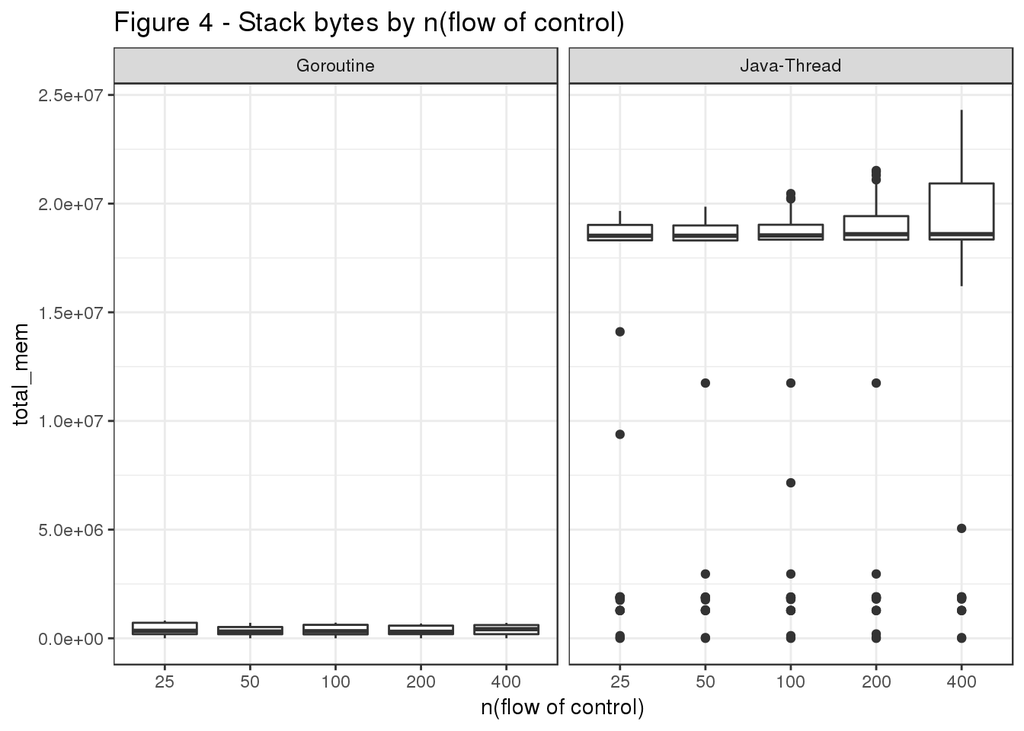

```r
data %>%
  ggplot(aes(nflows,total_mem)) +
  geom_boxplot() +
  facet_wrap(~ impl) +
  labs(x="n(flow of control)",
       title="Figure 4 - Stack bytes by n(flow of control)")
```

- In this chart we get a clear picture that *Java-Threads* have a larger total memory consumption than *Goroutines* across all testes number of flows of control.

## Analysis by number of flows of control

In order to visualize data from the point of view of n(flow of control) let’s reshape the data.

```r
data %>%
  as_data_frame() %>%
  melt(id.vars=c("impl","snapshot","nflows","time"),
       measure.vars=c("total_mem","mem_heap_B",
                      "mem_heap_extra_B","mem_stacks_B")) -> melt_data

melt_data %>%
  sample_n(10)
```

|  | impl | snapshot | nflows | time | variable | value |
| --- | --- | --- | --- | --- | --- | --- |
| 946 | Java-Thread | 55 | 50 | 358102288 | mem_heap_B | 19542093 |
| 558 | Goroutine | 8 | 400 | 92884176 | total_mem | 104544 |
| 2028 | Java-Thread | 5 | 400 | 37888336 | mem_heap_extra_B | 13487 |
| 2080 | Java-Thread | 57 | 400 | 454789512 | mem_heap_extra_B | 113761 |
| 1181 | Java-Thread | 11 | 200 | 69050664 | mem_heap_B | 1857444 |
| 1524 | Java-Thread | 66 | 25 | 348008840 | mem_heap_extra_B | 34043 |
| 1891 | Java-Thread | 27 | 200 | 174891784 | mem_heap_extra_B | 22909 |
| 1740 | Java-Thread | 32 | 100 | 162156096 | mem_heap_extra_B | 22443 |
| 2757 | Java-Thread | 40 | 400 | 340423928 | mem_stacks_B | 39800 |
| 811 | Java-Thread | 47 | 25 | 277459912 | mem_heap_B | 18895250 |

#### n(flow of control) = 25

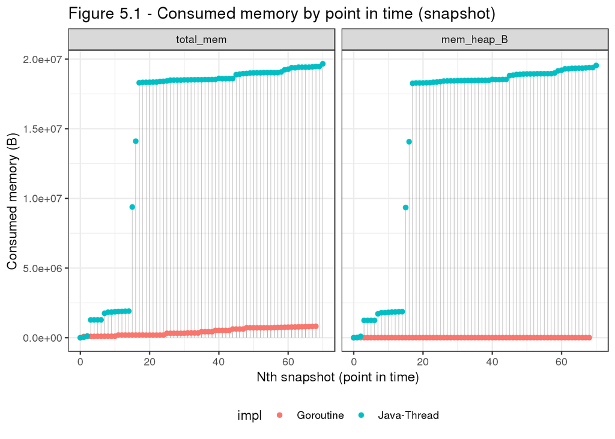

```r
melt_data %>%
  filter(nflows == 25) %>%
  filter(variable %in% c("total_mem","mem_heap_B")) %>%
  ggplot(aes(snapshot,value, color=impl)) +
  geom_segment(aes(x = snapshot, y = 0,
                     xend = snapshot, yend = value),
                 color = "grey50", size=0.1) +
  geom_point() +
  facet_wrap(~ variable) +
  theme(legend.position = "bottom") +
  labs(y="Consumed memory (B)",
       x="Nth snapshot (point in time)",
       title="Figure 5.1 - Consumed memory by point in time (snapshot)")
```

- Results concur those of Figure 1 and Figure 4.

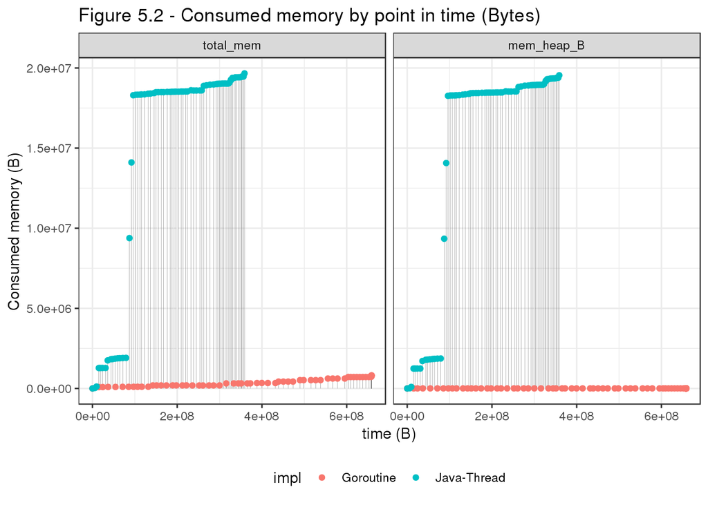

```r
melt_data %>%
  filter(nflows == 25) %>%
  filter(variable %in% c("total_mem","mem_heap_B")) %>%
  ggplot(aes(time,value, color=impl)) +
  geom_segment(aes(x = time, y = 0,
                     xend = time, yend = value),
                 color = "grey50", size=0.1) +
  geom_point() +
  facet_wrap(~ variable) +
  theme(legend.position = "bottom") +
  labs(y="Consumed memory (B)",
       x="time (B)",
       title="Figure 5.2 - Consumed memory by point in time (Bytes)")
```

- Using bytes as time unit the *Goroutines*’ executions were longer.
- In terms of consumed memory, the results concur those of Figure 5.1

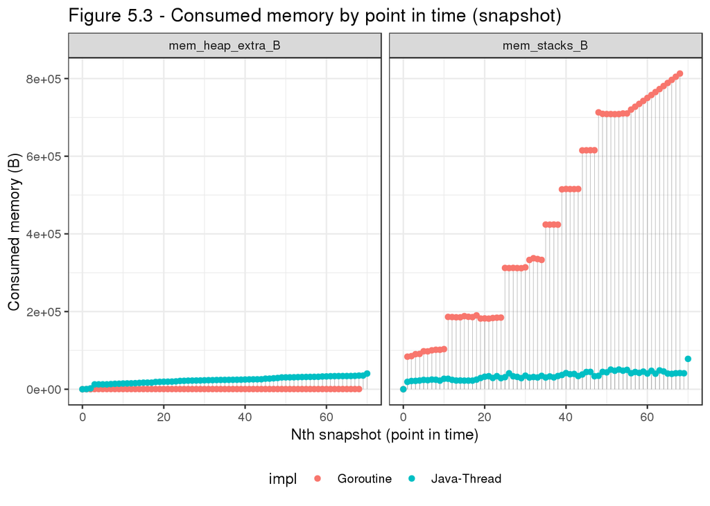

```r
melt_data %>%
  filter(nflows == 25) %>%
  filter(variable %in% c("mem_heap_extra_B","mem_stacks_B")) %>%
  ggplot(aes(snapshot,value, color=impl)) +
  geom_segment(aes(x = snapshot, y = 0,
                     xend = snapshot, yend = value),
                 color = "grey50", size=0.1) +
  geom_point() +
  facet_wrap(~ variable) +
  theme(legend.position = "bottom") +
  labs(y="Consumed memory (B)",
       x="Nth snapshot (point in time)",
       title="Figure 5.3 - Consumed memory by point in time (snapshot)")
```

- Results concur those of Figure 2 and Figure 3.

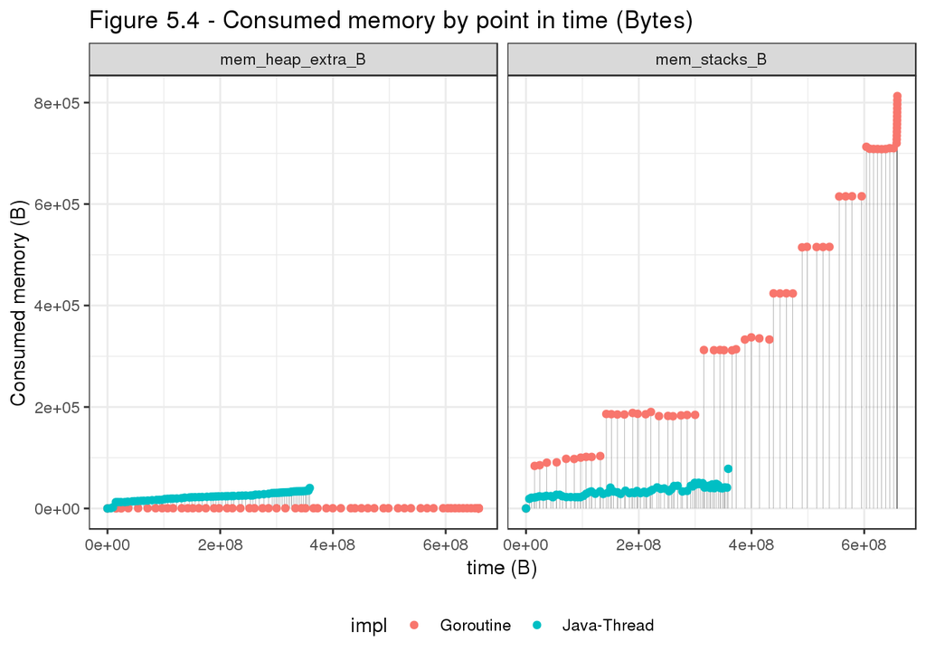

```r
melt_data %>%
  filter(nflows == 25) %>%
  filter(variable %in% c("mem_heap_extra_B","mem_stacks_B")) %>%
  ggplot(aes(time,value, color=impl)) +
  geom_segment(aes(x = time, y = 0,
                     xend = time, yend = value),
                 color = "grey50", size=0.1) +
  geom_point() +
  facet_wrap(~ variable) +
  theme(legend.position = "bottom") +
  labs(y="Consumed memory (B)",
       x="time (B)",
       title="Figure 5.4 - Consumed memory by point in time (Bytes)")
```

- Using bytes as time unit the *Goroutines*’ executions were longer.
- In terms of consumed memory, the results concur those of Figure 5.3
  - Results for *mem_heap_extra_B* are less clear here, but crossing the results by snapshot, the evidence supports the idea that *Java-Threads* consumed more.

#### n(flow of control) = 50

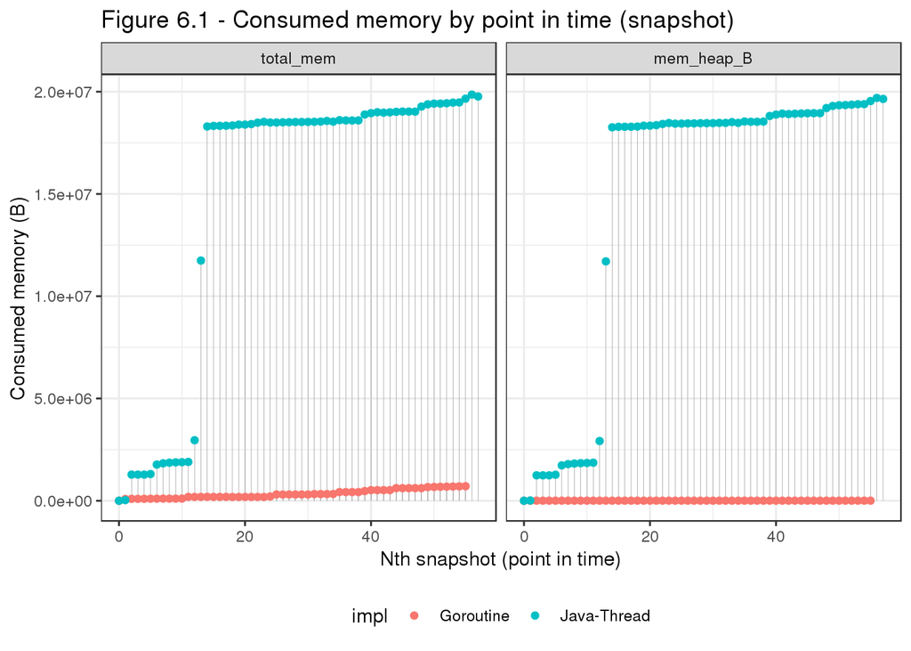

```r
melt_data %>%
  filter(nflows == 50) %>%
  filter(variable %in% c("total_mem","mem_heap_B")) %>%
  ggplot(aes(snapshot,value, color=impl)) +
  geom_segment(aes(x = snapshot, y = 0,
                     xend = snapshot, yend = value),
                 color = "grey50", size=0.1) +
  geom_point() +
  facet_wrap(~ variable) +
  theme(legend.position = "bottom") +
  labs(y="Consumed memory (B)",
       x="Nth snapshot (point in time)",
       title="Figure 6.1 - Consumed memory by point in time (snapshot)")
```

- Results concur those of Figure 1 and Figure 4.

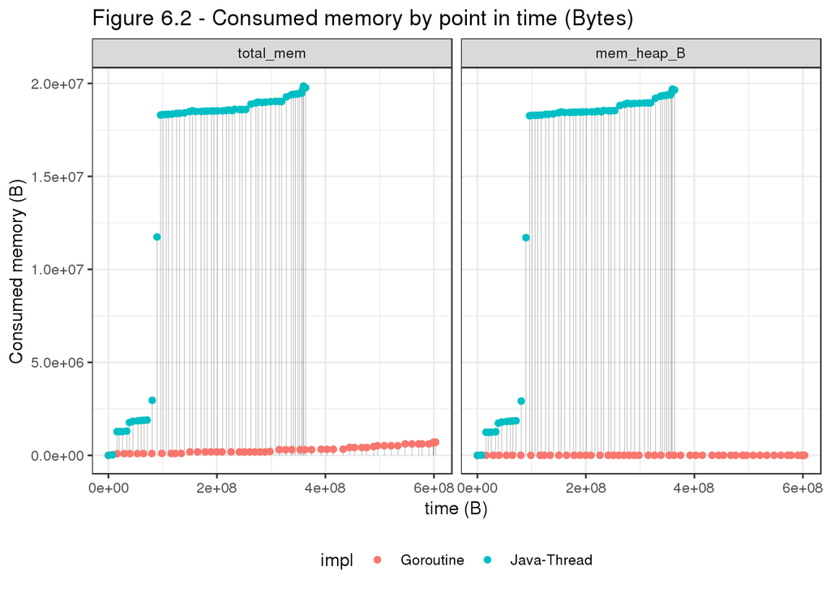

```r
melt_data %>%
  filter(nflows == 50) %>%
  filter(variable %in% c("total_mem","mem_heap_B")) %>%
  ggplot(aes(time,value, color=impl)) +
  geom_segment(aes(x = time, y = 0,
                     xend = time, yend = value),
                 color = "grey50", size=0.1) +
  geom_point() +
  facet_wrap(~ variable) +
  theme(legend.position = "bottom") +
  labs(y="Consumed memory (B)",
       x="time (B)",
       title="Figure 6.2 - Consumed memory by point in time (Bytes)")
```

- Using bytes as time unit the *Goroutines*’ executions were longer.
- In terms of consumed memory, the results concur those of Figure 6.1

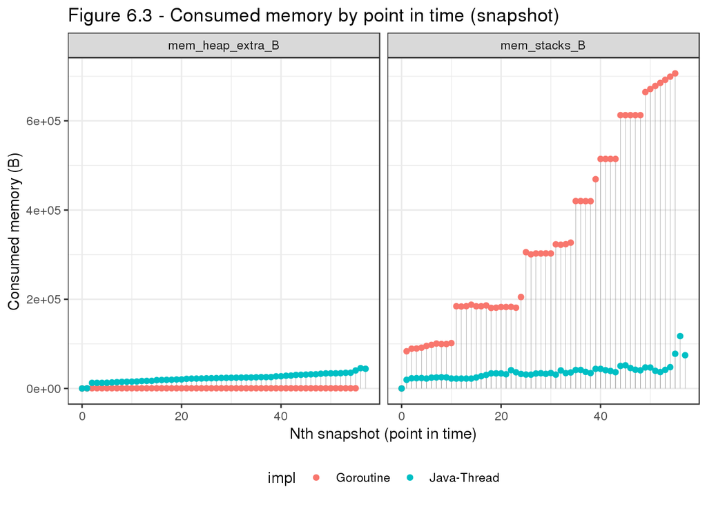

```r
melt_data %>%
  filter(nflows == 50) %>%
  filter(variable %in% c("mem_heap_extra_B","mem_stacks_B")) %>%
  ggplot(aes(snapshot,value, color=impl)) +
  geom_segment(aes(x = snapshot, y = 0,
                     xend = snapshot, yend = value),
                 color = "grey50", size=0.1) +
  geom_point() +
  facet_wrap(~ variable) +
  theme(legend.position = "bottom") +
  labs(y="Consumed memory (B)",
       x="Nth snapshot (point in time)",
       title="Figure 6.3 - Consumed memory by point in time (snapshot)")
```

- Results concur those of Figure 2 and Figure 3.

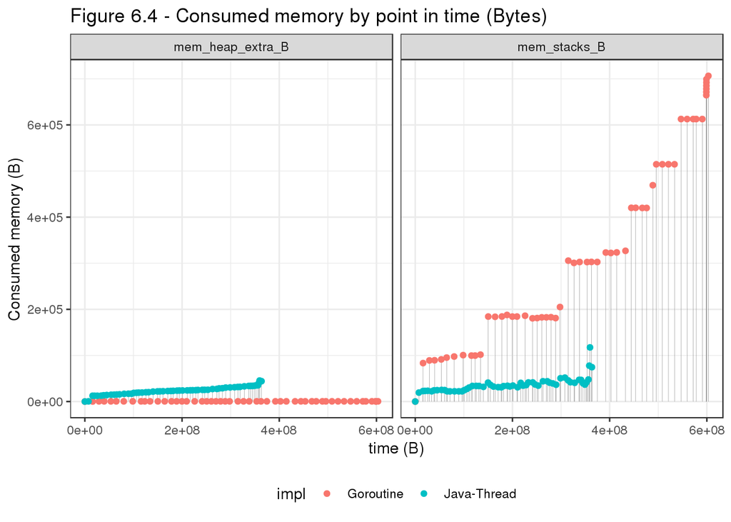

```r
melt_data %>%
  filter(nflows == 50) %>%
  filter(variable %in% c("mem_heap_extra_B","mem_stacks_B")) %>%
  ggplot(aes(time,value, color=impl)) +
  geom_segment(aes(x = time, y = 0,
                     xend = time, yend = value),
                 color = "grey50", size=0.1) +
  geom_point() +
  facet_wrap(~ variable) +
  theme(legend.position = "bottom") +
  labs(y="Consumed memory (B)",
       x="time (B)",
       title="Figure 6.4 - Consumed memory by point in time (Bytes)")
```

- Using bytes as time unit the *Goroutines*’ executions were longer.
- In terms of consumed memory, the results concur those of Figure 6.3

#### n(flow of control) = 100

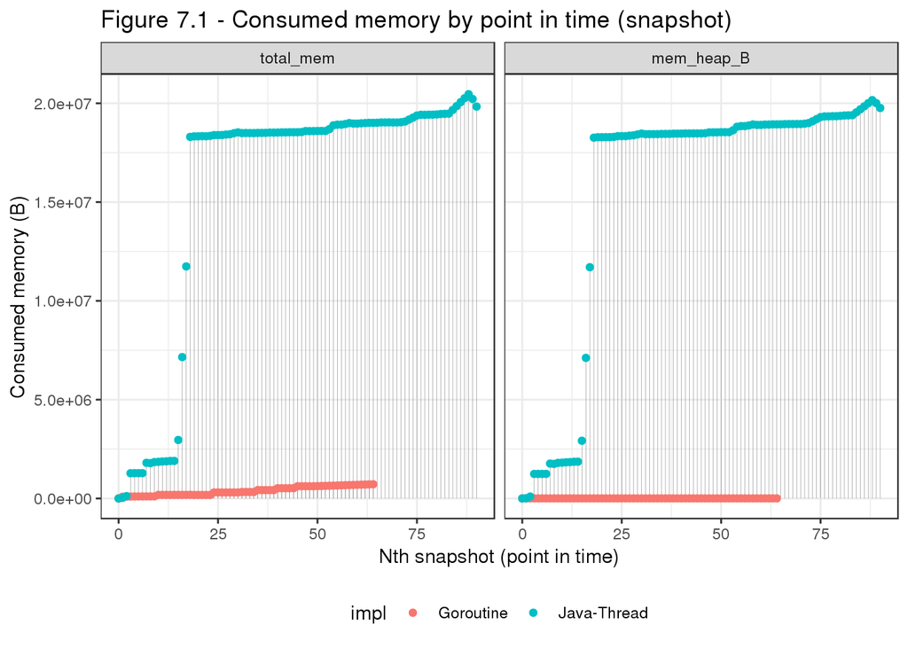

```r
melt_data %>%
  filter(nflows == 100) %>%
  filter(variable %in% c("total_mem","mem_heap_B")) %>%
  ggplot(aes(snapshot,value, color=impl)) +
  geom_segment(aes(x = snapshot, y = 0,
                     xend = snapshot, yend = value),
                 color = "grey50", size=0.1) +
  geom_point() +
  facet_wrap(~ variable) +
  theme(legend.position = "bottom") +
  labs(y="Consumed memory (B)",
       x="Nth snapshot (point in time)",
       title="Figure 7.1 - Consumed memory by point in time (snapshot)")
```

- Results clearly concur those of Figure 1 and Figure 4.

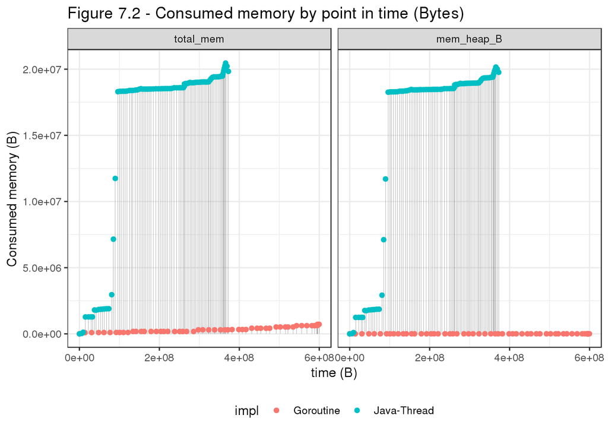

```r
melt_data %>%
  filter(nflows == 100) %>%
  filter(variable %in% c("total_mem","mem_heap_B")) %>%
  ggplot(aes(time,value, color=impl)) +
  geom_segment(aes(x = time, y = 0,
                     xend = time, yend = value),
                 color = "grey50", size=0.1) +
  geom_point() +
  facet_wrap(~ variable) +
  theme(legend.position = "bottom") +
  labs(y="Consumed memory (B)",
       x="time (B)",
       title="Figure 7.2 - Consumed memory by point in time (Bytes)")
```

- Using bytes as time unit the *Goroutines*’ executions were longer.
- In terms of consumed memory, the results concur those of Figure 7.1

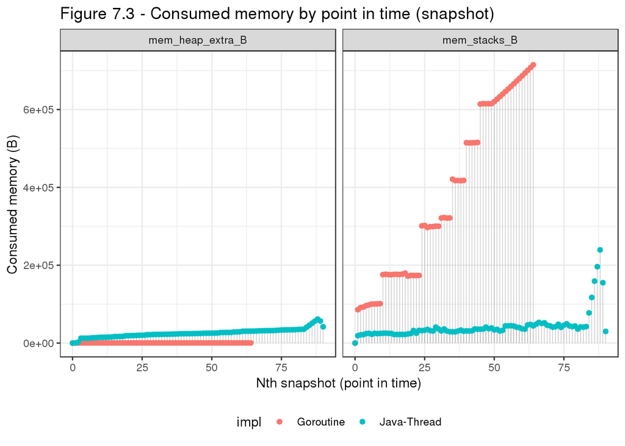

```r
melt_data %>%
  filter(nflows == 100) %>%
  filter(variable %in% c("mem_heap_extra_B","mem_stacks_B")) %>%
  ggplot(aes(snapshot,value, color=impl)) +
  geom_segment(aes(x = snapshot, y = 0,
                     xend = snapshot, yend = value),
                 color = "grey50", size=0.1) +
  geom_point() +
  facet_wrap(~ variable) +
  theme(legend.position = "bottom") +
  labs(y="Consumed memory (B)",
       x="Nth snapshot (point in time)",
       title="Figure 7.3 - Consumed memory by point in time (snapshot)")
```

- Results concur those of Figure 2 and Figure 3.
  - Although the higher cost in static memory for *Goroutines* is clear, the *Java-Threads* are increasing in consumption, especially at the time of the last snapshots.

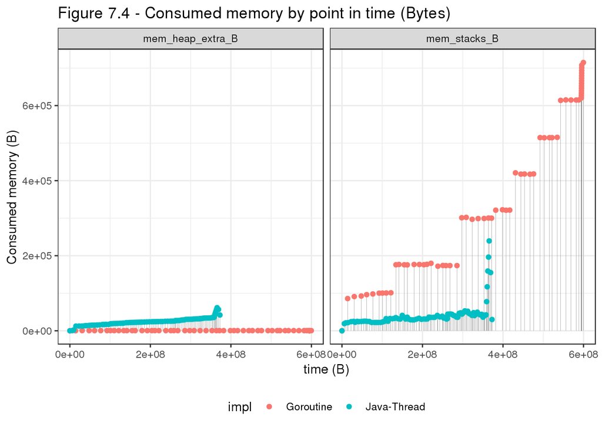

```r
melt_data %>%
  filter(nflows == 100) %>%
  filter(variable %in% c("mem_heap_extra_B","mem_stacks_B")) %>%
  ggplot(aes(time,value, color=impl)) +
  geom_segment(aes(x = time, y = 0,
                     xend = time, yend = value),
                 color = "grey50", size=0.1) +
  geom_point() +
  facet_wrap(~ variable) +
  theme(legend.position = "bottom") +
  labs(y="Consumed memory (B)",
       x="time (B)",
       title="Figure 7.4 - Consumed memory by point in time (Bytes)")
```

- Using bytes as time unit the *Goroutines*’ executions were longer.
- In terms of consumed memory, the results concur those of Figure 7.3

#### n(flow of control) = 200

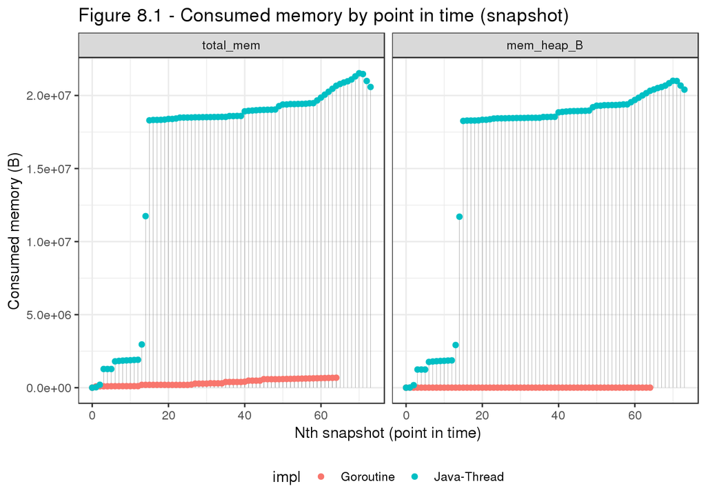

```r
melt_data %>%
  filter(nflows == 200) %>%
  filter(variable %in% c("total_mem","mem_heap_B")) %>%
  ggplot(aes(snapshot,value, color=impl)) +
  geom_segment(aes(x = snapshot, y = 0,
                     xend = snapshot, yend = value),
                 color = "grey50", size=0.1) +
  geom_point() +
  facet_wrap(~ variable) +
  theme(legend.position = "bottom") +
  labs(y="Consumed memory (B)",
       x="Nth snapshot (point in time)",
       title="Figure 8.1 - Consumed memory by point in time (snapshot)")
```

- Results clearly concur those of Figure 1 and Figure 4.

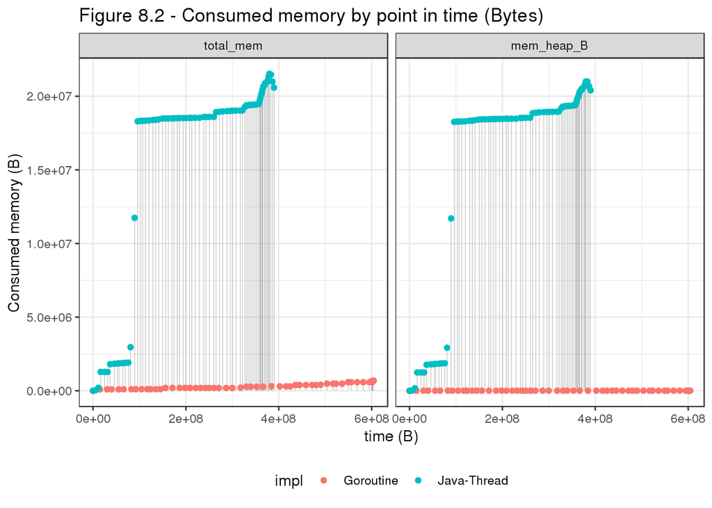

```r
melt_data %>%
  filter(nflows == 200) %>%
  filter(variable %in% c("total_mem","mem_heap_B")) %>%
  ggplot(aes(time,value, color=impl)) +
  geom_segment(aes(x = time, y = 0,
                     xend = time, yend = value),
                 color = "grey50", size=0.1) +
  geom_point() +
  facet_wrap(~ variable) +
  theme(legend.position = "bottom") +
  labs(y="Consumed memory (B)",
       x="time (B)",
       title="Figure 8.2 - Consumed memory by point in time (Bytes)")
```

- Using bytes as time unit the *Goroutines*’ executions were longer.
- In terms of consumed memory, the results concur those of Figure 8.1

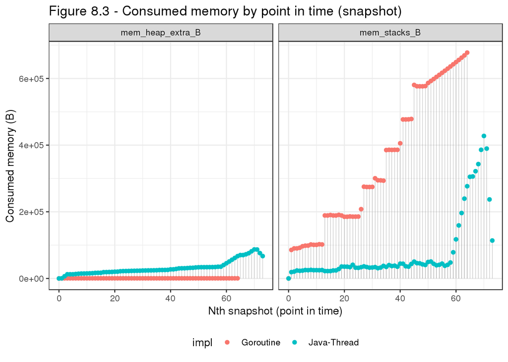

```r
melt_data %>%
  filter(nflows == 200) %>%
  filter(variable %in% c("mem_heap_extra_B","mem_stacks_B")) %>%
  ggplot(aes(snapshot,value, color=impl)) +
  geom_segment(aes(x = snapshot, y = 0,
                     xend = snapshot, yend = value),
                 color = "grey50", size=0.1) +
  geom_point() +
  facet_wrap(~ variable) +
  theme(legend.position = "bottom") +
  labs(y="Consumed memory (B)",
       x="Nth snapshot (point in time)",
       title="Figure 8.3 - Consumed memory by point in time (snapshot)")
```

- Results concur those of Figure 2 and Figure 3.
- The cost in static memory is higher for *Goroutines*.
  - The trend of consumption increase for *Java-Threads* strengthens, especially at the time of the last snapshots.

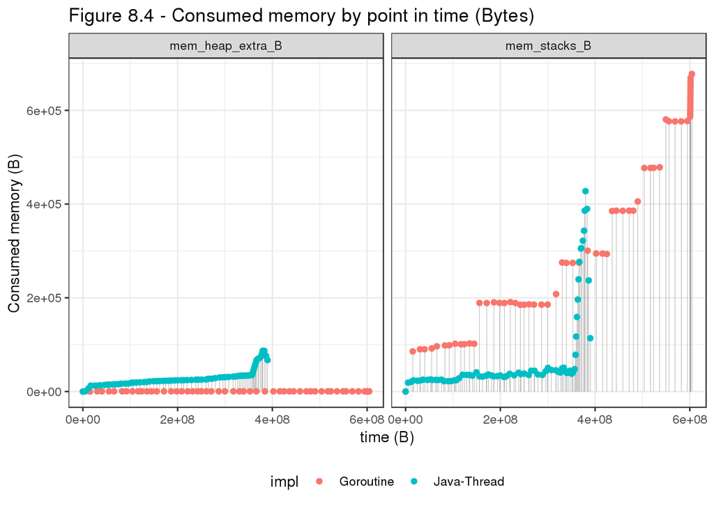

```r
melt_data %>%
  filter(nflows == 200) %>%
  filter(variable %in% c("mem_heap_extra_B","mem_stacks_B")) %>%
  ggplot(aes(time,value, color=impl)) +
  geom_segment(aes(x = time, y = 0,
                     xend = time, yend = value),
                 color = "grey50", size=0.1) +
  geom_point() +
  facet_wrap(~ variable) +
  theme(legend.position = "bottom") +
  labs(y="Consumed memory (B)",
       x="time (B)",
       title="Figure 8.4 - Consumed memory by point in time (Bytes)")
```

- Using bytes as time unit the *Goroutines*’ executions were longer.
- In terms of consumed memory, the results concur those of Figure 8.3
  - Results for *mem_heap_extra_B* are less clear here, but crossing the results by snapshot, the evidence supports the idea that *Java-Threads* consumed more.

#### n(flow of control) = 400

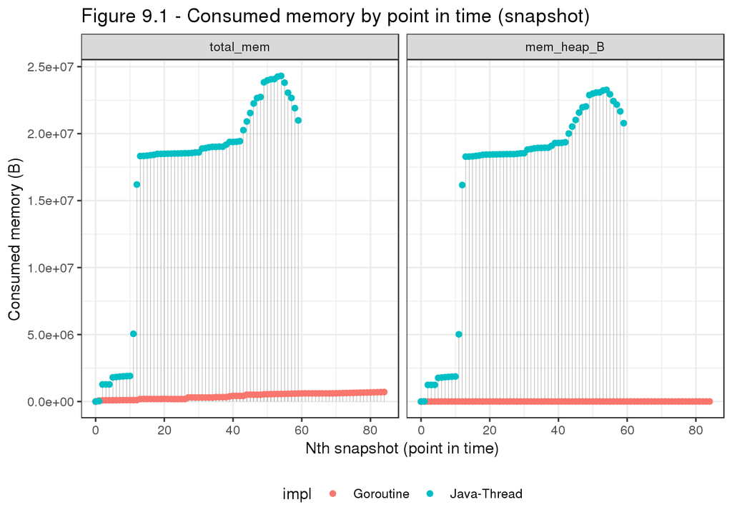

```r
melt_data %>%
  filter(nflows == 400) %>%
  filter(variable %in% c("total_mem","mem_heap_B")) %>%
  ggplot(aes(snapshot,value, color=impl)) +
  geom_segment(aes(x = snapshot, y = 0,
                     xend = snapshot, yend = value),
                 color = "grey50", size=0.1) +
  geom_point() +
  facet_wrap(~ variable) +
  theme(legend.position = "bottom") +
  labs(y="Consumed memory (B)",
       x="Nth snapshot (point in time)",
       title="Figure 9.1 - Consumed memory by point in time (snapshot)")
```

- The *Goroutine* execution has more snapshots but this is overshadowed by the much larger memory consumption of the *Java-Threads*
- Results concur those of Figure 1 and Figure 4 despite the increase in snapshots for the *Goroutine* execution.

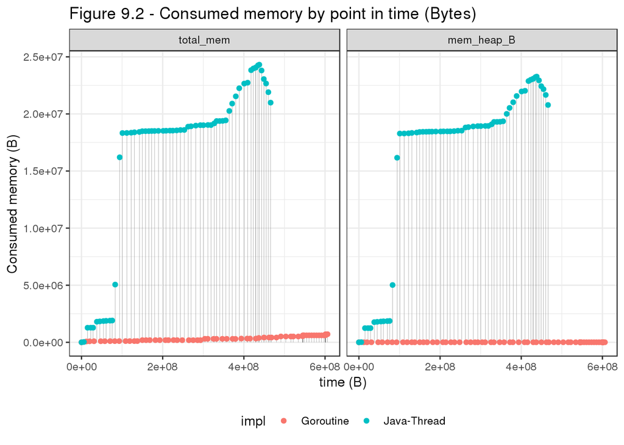

```r
melt_data %>%
  filter(nflows == 400) %>%
  filter(variable %in% c("total_mem","mem_heap_B")) %>%
  ggplot(aes(time,value, color=impl)) +
  geom_segment(aes(x = time, y = 0,
                     xend = time, yend = value),
                 color = "grey50", size=0.1) +
  geom_point() +
  facet_wrap(~ variable) +
  theme(legend.position = "bottom") +
  labs(y="Consumed memory (B)",
       x="time (B)",
       title="Figure 9.2 - Consumed memory by point in time (Bytes)")
```

- Using bytes as time unit the *Goroutines*’ executions were longer.
- In terms of consumed memory, the results concur those of Figure 9.1

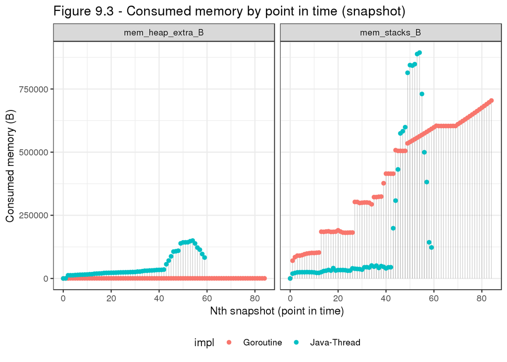

```r
melt_data %>%
  filter(nflows == 400) %>%
  filter(variable %in% c("mem_heap_extra_B","mem_stacks_B")) %>%
  ggplot(aes(snapshot,value, color=impl)) +
  geom_segment(aes(x = snapshot, y = 0,
                     xend = snapshot, yend = value),
                 color = "grey50", size=0.1) +
  geom_point() +
  facet_wrap(~ variable) +
  theme(legend.position = "bottom") +
  labs(y="Consumed memory (B)",
       x="Nth snapshot (point in time)",
       title="Figure 9.3 - Consumed memory by point in time (snapshot)")
```

- Results concur those of Figure 2 and Figure 3.
- The cost in static memory is higher for *Goroutines* although it becomes less clear in this instance.
  - The trend of consumption increase for *Java-Threads* strengthens, especially at the time of its last snapshots.

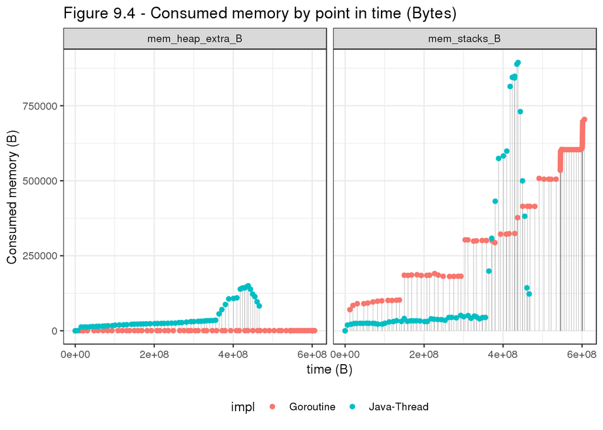

```r
melt_data %>%
  filter(nflows == 400) %>%
  filter(variable %in% c("mem_heap_extra_B","mem_stacks_B")) %>%
  ggplot(aes(time,value, color=impl)) +
  geom_segment(aes(x = time, y = 0,
                     xend = time, yend = value),
                 color = "grey50", size=0.1) +
  geom_point() +
  facet_wrap(~ variable) +
  theme(legend.position = "bottom") +
  labs(y="Consumed memory (B)",
       x="time (B)",
       title="Figure 9.4 - Consumed memory by point in time (Bytes)")
```

- Using bytes as time unit the *Goroutines*’ executions were longer.
- In terms of consumed stack memory much like the results of Figure 8.3 the difference becomes less clear, though it seems like *Goroutines* are still costlier.

## Summary

- From the analysis by metric:
  - *Goroutines* consume more stack memory (static).
  - *Java-Threads* consume more heap memory (dynamic).
  - In total, *Java-Threads* consumed more memory.

> In total, *Java-Threads* consumed more memory.
- From the analysis by n(flow of control):
  - Overall the results from the previous analysis were concurred.
  - Using bytes as time unit the *Goroutines*’ executions were longer
  - The higher static memory consumption from the *Goroutines* became less clear as the number of n(flow of control) increased

> Overall the results from the previous analysis were concurred.

### Conclusions

#### A reasoning that may partly explain the results seen in this report, is as follows:

> Java’s inherent Object Oriented paradigm produces references to objects and their types. For this reason Java produces entities of composite type, which implies in more dynamic allocation. This, in turn would explain the high memory consumption of the *Java-Threads*. Golang, in the other hand succeds in keeping more things in stack (less memory), as it produces less things of composite type.